# Project 1

## Occupation

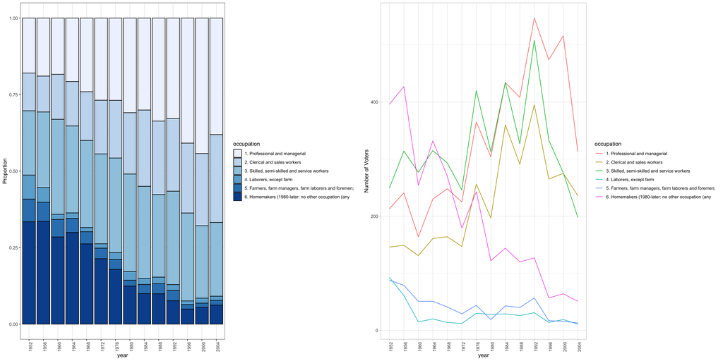

Over the past presidential elections, the proportion of homemakers has drastically decreased, whereas the proportion of professional and managerial has remarkably increased. The proportion of skilled, semi-skilled and service workers has remained approximately the same over time.

# gender gaps

```r
gap <- data %>% select(gender,year,vote) %>% filter(!is.na(gender) & gender != '3. Other (2016)') %>%
  group_by(gender,vote,year) %>% count() %>%
  filter(vote %in% c('Democrat','Republican')) %>%
  pivot_wider(names_from = c(vote,gender), values_from = n) %>%
  pivot_longer(-year, names_to = 'variable', values_to = 'count') %>%
  mutate(variable = as_factor(variable))
```

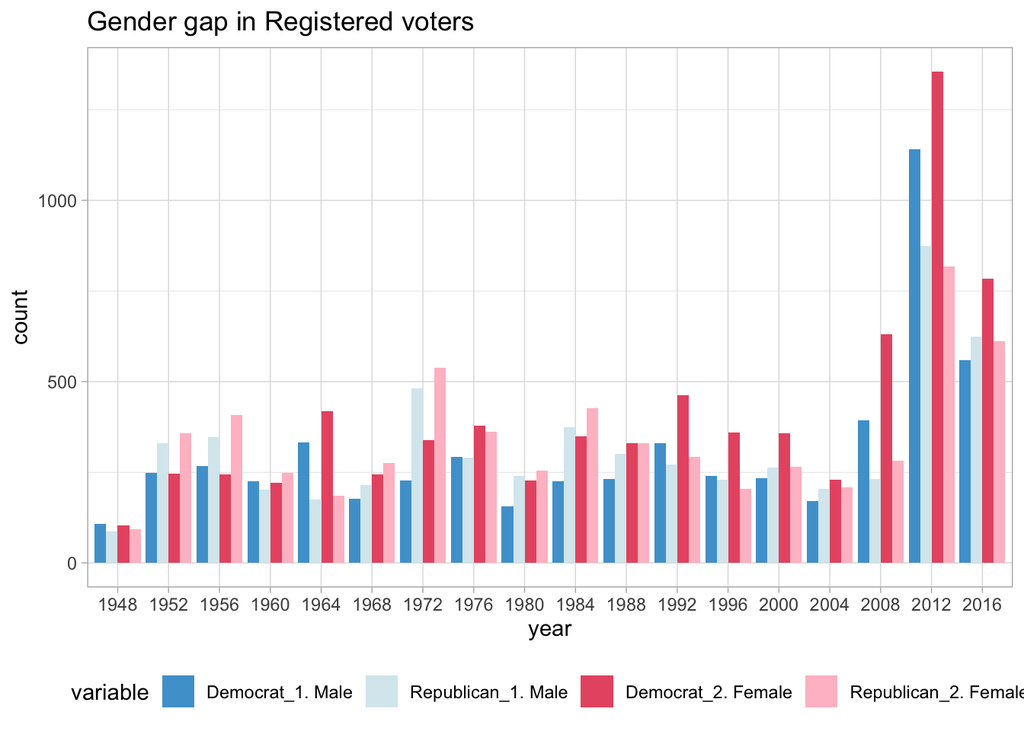

```r
#levels(gap$variable)
ggplot(gap) +geom_bar(stat = 'identity',aes(x=year,y=count,fill = variable),position ='dodge')+
  scale_fill_manual(values=c('#4ea1d3', "#d8e9ef","#e85a71","pink"))+
  labs(title = 'Gender gap in Registered voters')+
  theme_light()+
  theme(legend.position = 'bottom')
```

The gender gap in voting refers to the difference in the percentage of women and the percentage of men voting for a given candidate. With blues representing male’s votes and pink representing female’s votes, the graph shows different preference between men and women. I would say there is a gender gap in 1980 as men voted more for republic while women vote two parties evenly. The gender gap is more obvious in recent years. In 2000, more women vote for democratic and men vote oppositely more to republic. Same scenario in 2004 and 2016.